# Coronavirus US - All-Cause Death

davegoblue

2022-06-23

## Background

This module extends code contained in Coronavirus_Statistics_v005.Rmd to include sourcing of updated functions and parameters. This file includes the latest code for analyzing all-cause death data from [CDC Weekly Deaths by Jurisdiction](https://catalog.data.gov/dataset/weekly-counts-of-deaths-by-jurisdiction-and-age-group). CDC maintains data on deaths by week, age cohort, and state in the US. Downloaded data are unique by state, epidemiological week, year, age, and type (actual vs. predicted/projected).

These data are known to have a lag between death and reporting, and the CDC back-correct to report deaths at the time the death occurred even if the death is reported in following weeks. This means totals for recent weeks tend to run low (lag), and the CDC run a projection of the expected total number of deaths given the historical lag times. Per other analysts on the internet, there is currently significant supra-lag, with lag times much longer than historical averages causing CDC projected deaths for recent weeks to be low.

The code leverages tidyverse and sourced functions throughout:

```r
# All functions assume that tidyverse and its components are loaded and available
library(tidyverse)
# If the same function is in both files, use the version from the more specific source
source("./Generic_Added_Utility_Functions_202105_v001.R")
source("./Coronavirus_CDC_Excess_Functions_v001.R")
```

The basic process includes three data update steps:

```r
# STEP 0: Appropriate parameters for 2022 data
cdcExcessParams <- list(remapVars=c('Jurisdiction'='fullState',
                                    'Week Ending Date'='weekEnding',
                                    'State Abbreviation'='state',
                                    'Age Group'='age',
                                    'Number of Deaths'='deaths',
                                    'Time Period'='period',
                                    'Year'='year',
                                    'Week'='week'
                                    ),
                        colTypes="ccciicdcccc",
                        ageLevels=c("Under 25 years",
                                    "25-44 years",
                                    "45-64 years",
                                    "65-74 years",
                                    "75-84 years",
                                    "85 years and older"
                                    ),
                        periodLevels=c("2015-2019", "2020", "2021", "2022"),
                        periodKeep=c("2015-2019", "2020", "2021"),
                        yearLevels=2015:2022
                        )

# STEP 1: Latest CDC all-cause deaths data
cdcLoc <- "Weekly_counts_of_deaths_by_jurisdiction_and_age_group_downloaded_20220623.csv"
cdcList_20220623 <- readRunCDCAllCause(loc=cdcLoc,
                                       weekThru=21,
                                       lst=readFromRDS("cdc_daily_220602"),
                                       stateNoCheck=c(),
                                       pdfCluster=TRUE,
                                       pdfAge=TRUE
                                       )
```

```
##
## Parameter cvDeathThru has been set as: 2022-05-28
##
##
##  *** Data suppression checks ***
##
## Rows in states to be checked that have NA deaths or a note for suppression:
##   state weekEnding year week         age
## 1    SD 2022-04-30 2022   17 65-74 years
## 2    SD 2022-04-30 2022   17 75-84 years
##                                                  Suppress deaths
## 1 Suppressed (counts highly incomplete, <50% of expected)     NA
## 2 Suppressed (counts highly incomplete, <50% of expected)     NA
##
##
## Problems by state:
## # A tibble: 1 x 5
##   noCheck state problem     n deaths
##   <lgl>   <chr> <lgl>   <int>  <dbl>
## 1 FALSE   SD    TRUE        2     NA
##
##
## There are 2 rows with errors; maximum for any given state is 2 errors
##
##
## Data suppression checks passed
##
##
## *** File has been checked for uniqueness by: state year week age
##
## Rows: 106,840
## Columns: 12
## $ fullState  <chr> "Alabama", "Alabama", "Alabama", "Alabama", "Alabama", "Ala~
## $ weekEnding <date> 2015-01-10, 2015-01-10, 2015-01-10, 2015-01-10, 2015-01-10~
## $ state      <chr> "AL", "AL", "AL", "AL", "AL", "AL", "AL", "AL", "AL", "AL",~
## $ year       <fct> 2015, 2015, 2015, 2015, 2015, 2015, 2015, 2015, 2015, 2015,~
## $ week       <int> 1, 1, 1, 1, 1, 1, 2, 2, 2, 2, 2, 2, 3, 3, 3, 3, 3, 3, 4, 4,~
## $ age        <fct> Under 25 years, 25-44 years, 45-64 years, 65-74 years, 75-8~
## $ period     <fct> 2015-2019, 2015-2019, 2015-2019, 2015-2019, 2015-2019, 2015~
## $ Type       <chr> "Predicted (weighted)", "Predicted (weighted)", "Predicted ~
```

[output cut: 42 more lines]

```
##
##
## Checking variable combination: period Note
## # A tibble: 9 x 5
##   period   Note                                            n n_deaths_na  deaths
##   <fct>    <chr>                                       <dbl>       <dbl>   <dbl>
## 1 2015-20~ <NA>                                        72033           0  1.39e7
## 2 2020     Data in recent weeks are incomplete. Only ~   279           0  8.68e4
## 3 2020     <NA>                                        14555           0  3.35e6
## 4 2021     Data in recent weeks are incomplete. Only ~ 12116           0  2.42e6
## 5 2021     Data in recent weeks are incomplete. Only ~    10           0  2.58e2
## 6 2021     Data in recent weeks are incomplete. Only ~  2572           0  1.04e6
## 7 2022     Data in recent weeks are incomplete. Only ~  4347           0  1.06e6
## 8 2022     Data in recent weeks are incomplete. Only ~    76           0  1.80e4
## 9 2022     Data in recent weeks are incomplete. Only ~   852           0  1.90e5
```

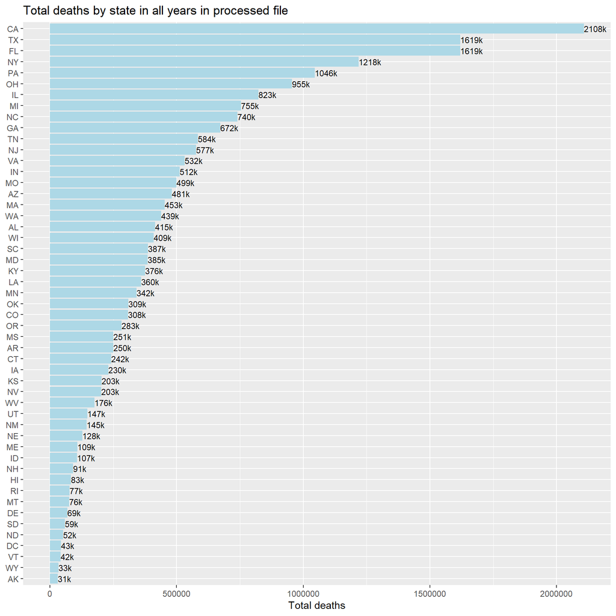

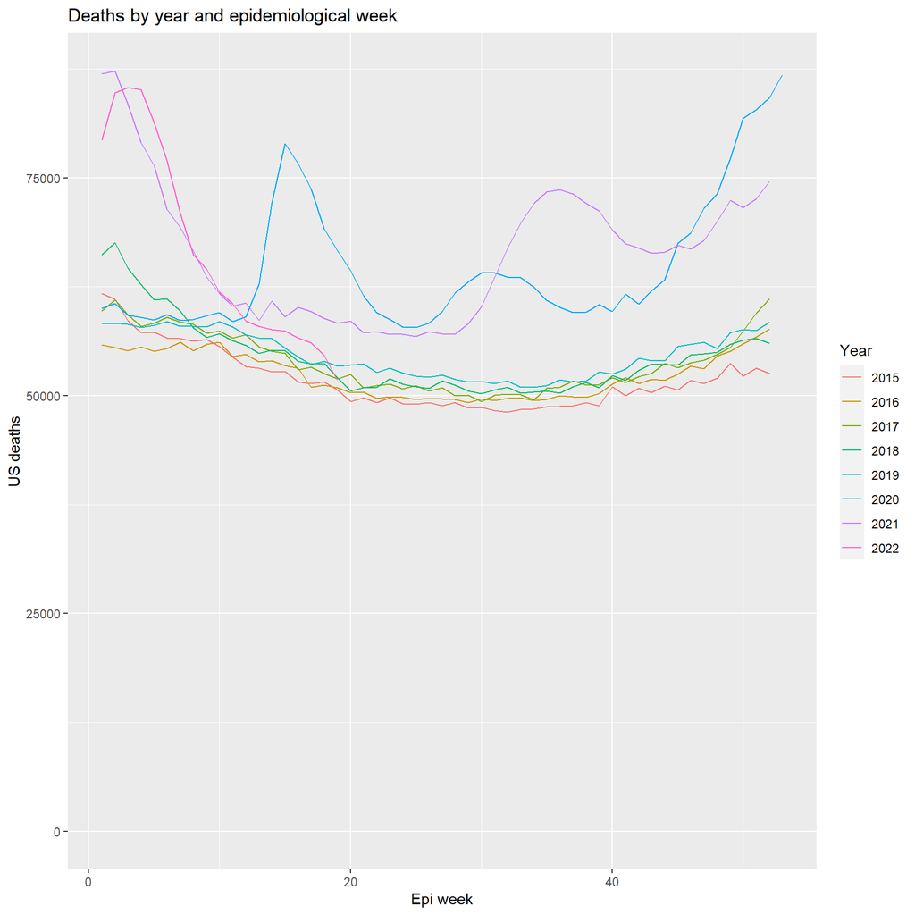

```
##
## *** File has been checked for uniqueness by: cluster year week
```

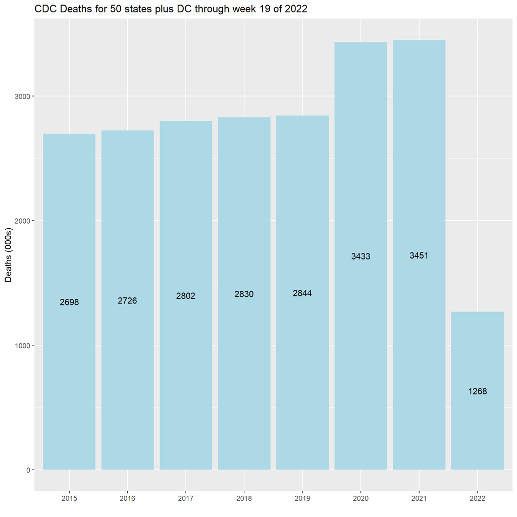

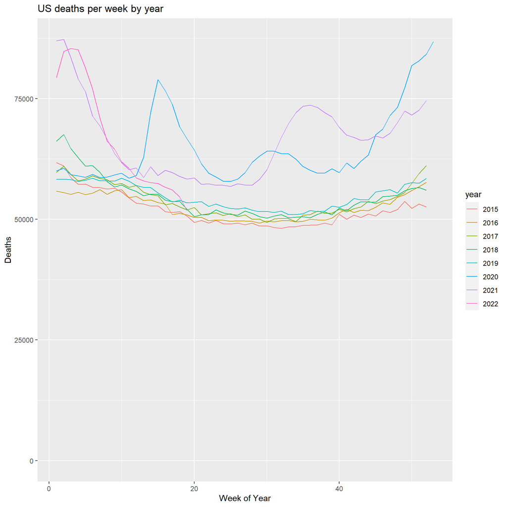

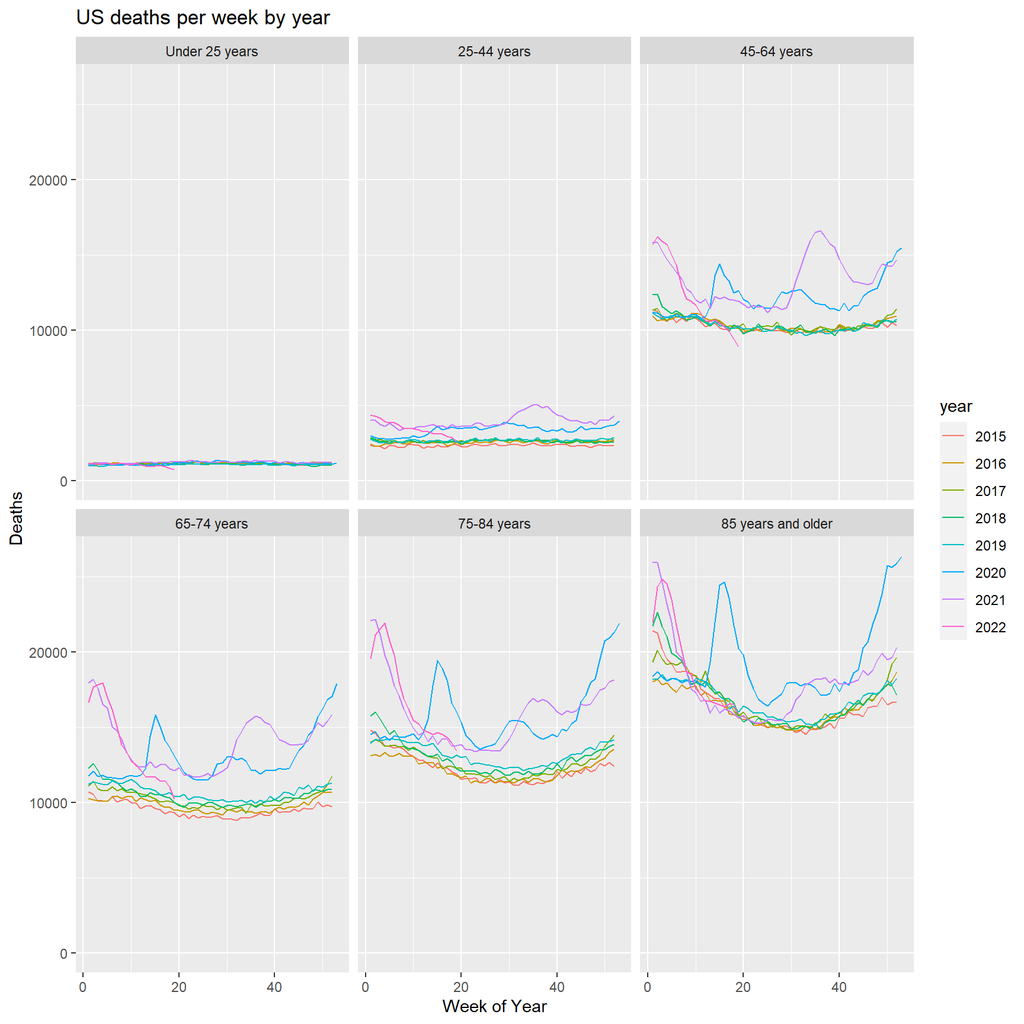

```
##
## Plots will be run after excluding stateNoCheck states
```

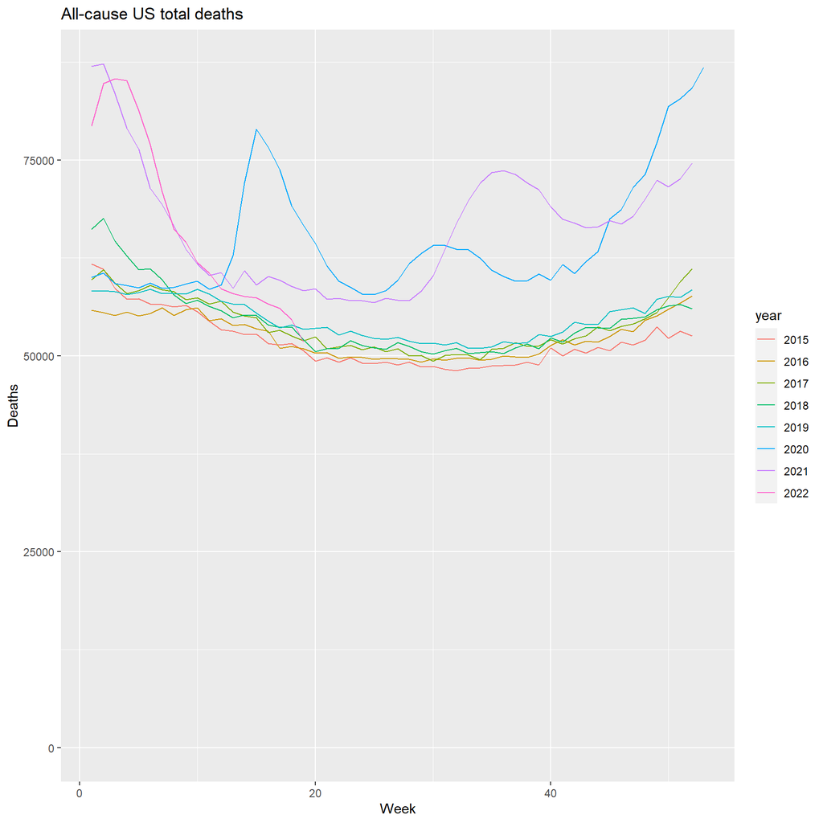

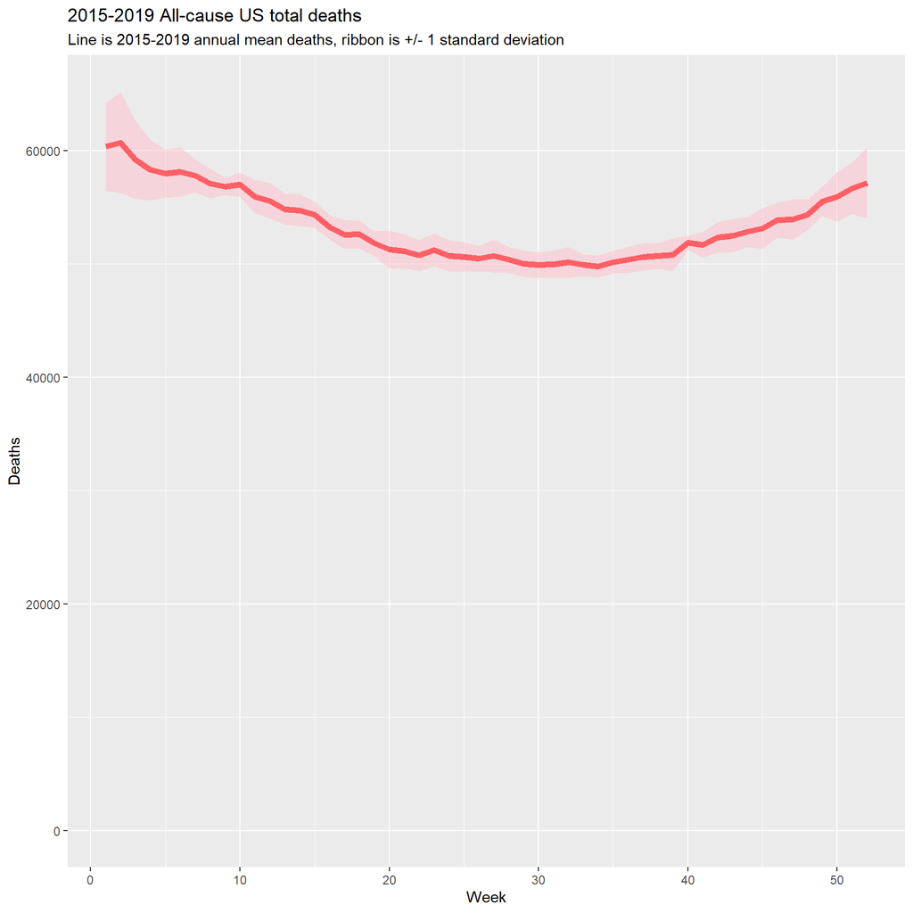

```
##
## Detailed cluster summary PDF file is available at: ./RInputFiles/Coronavirus/Plots/CDC_cluster_2022w21.pdf
```

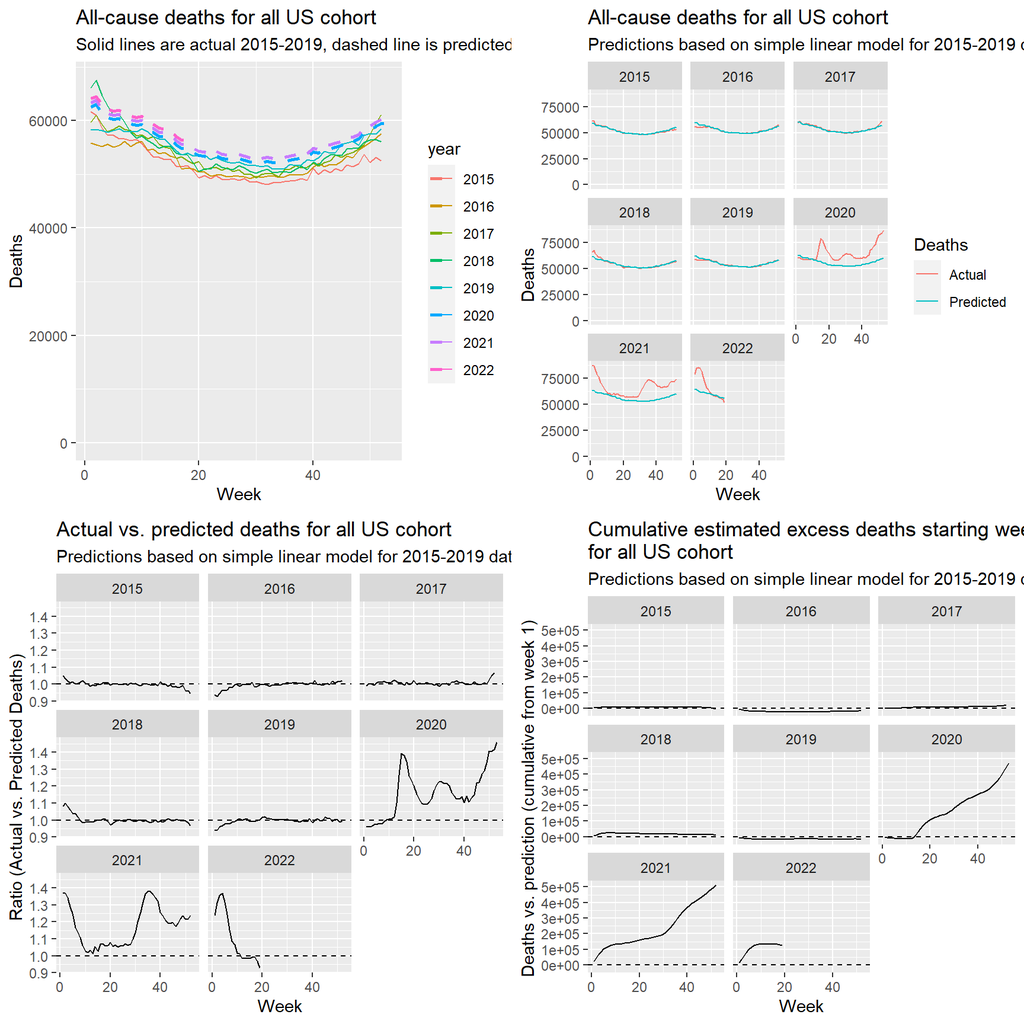

```
##
## Returning plot outputs to the main log file
```

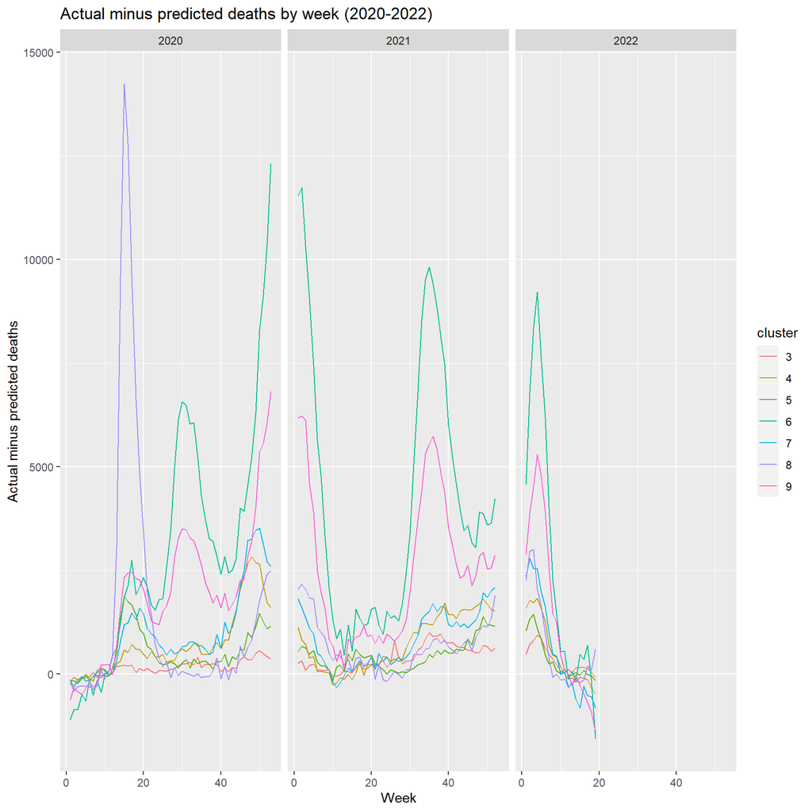

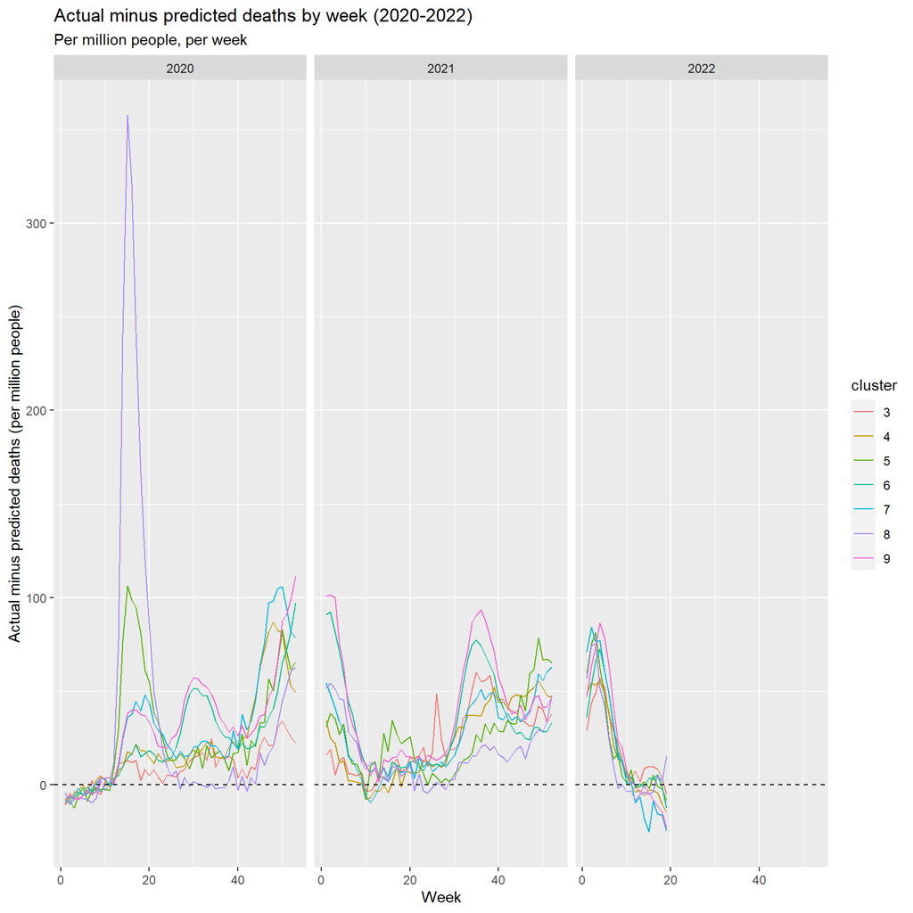

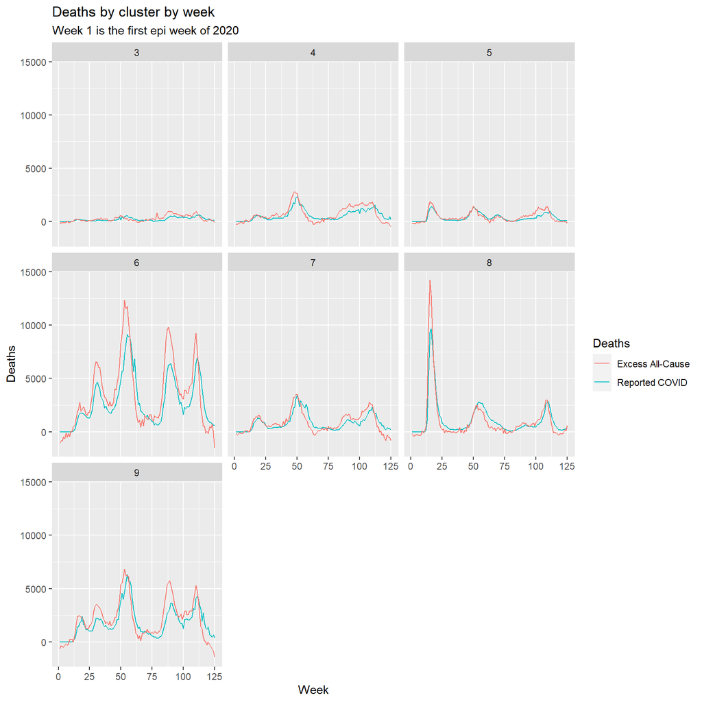

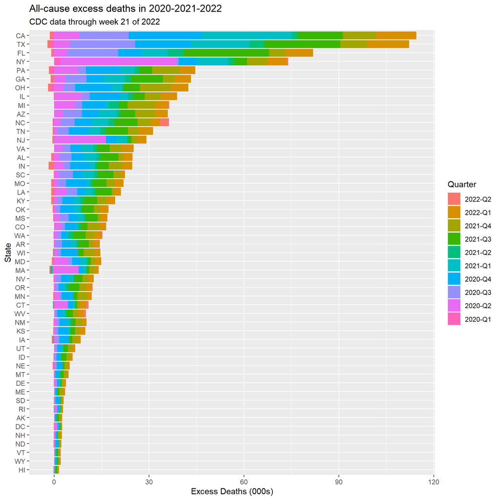

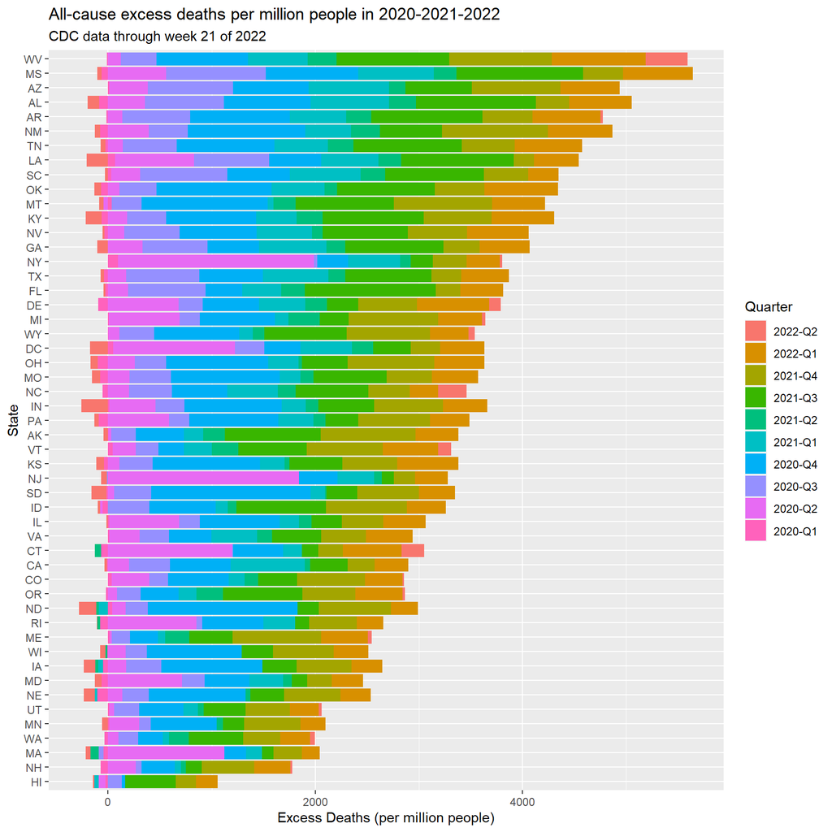

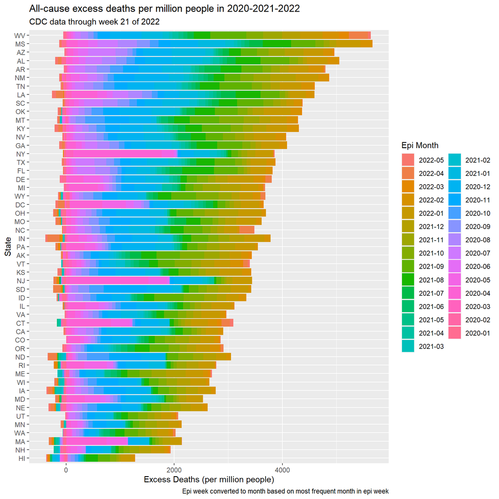

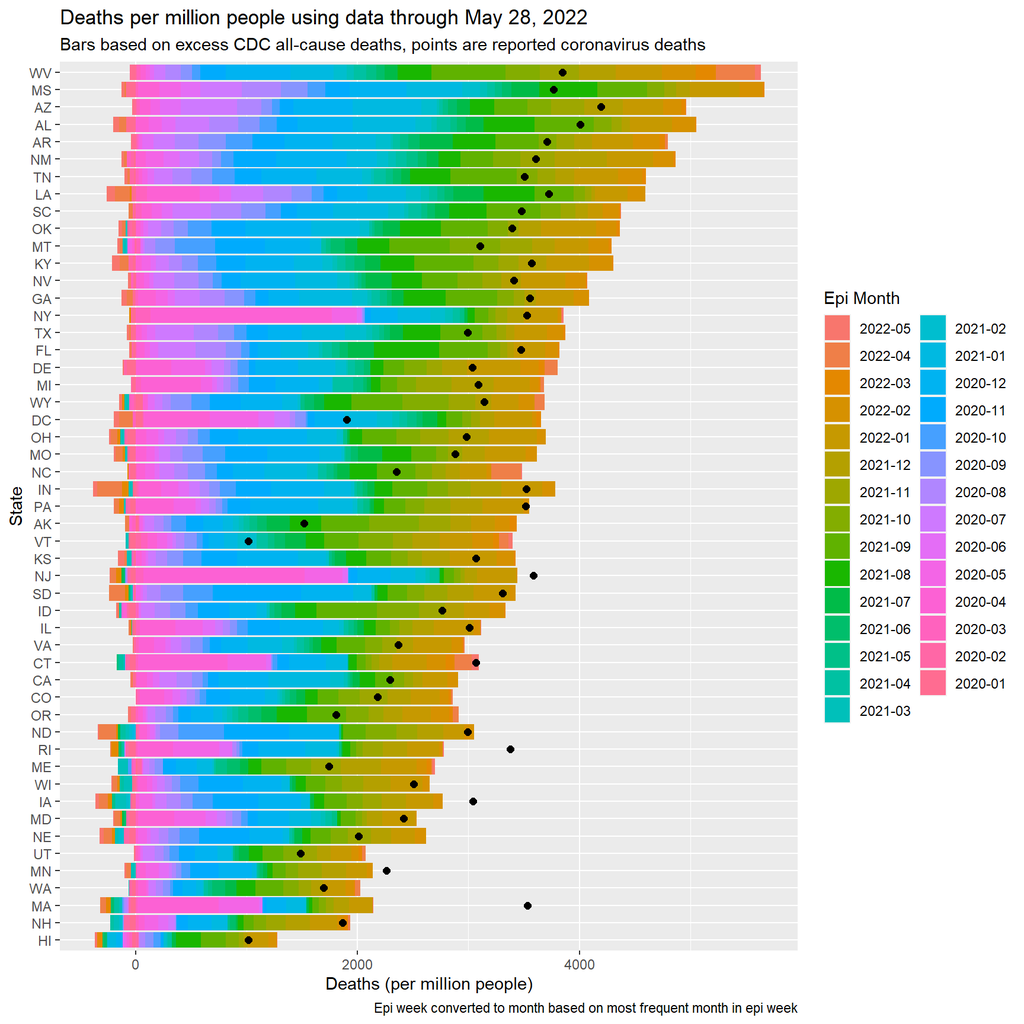

```
##
## Detailed age summary PDF file is available at: ./RInputFiles/Coronavirus/Plots/CDC_age_2022w21.pdf
```

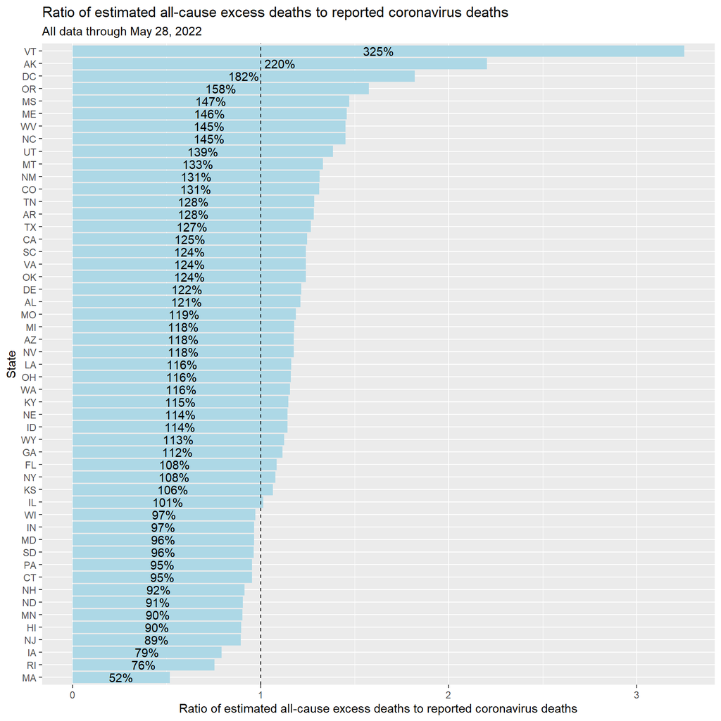

```
##
## Returning plot outputs to the main log file
```

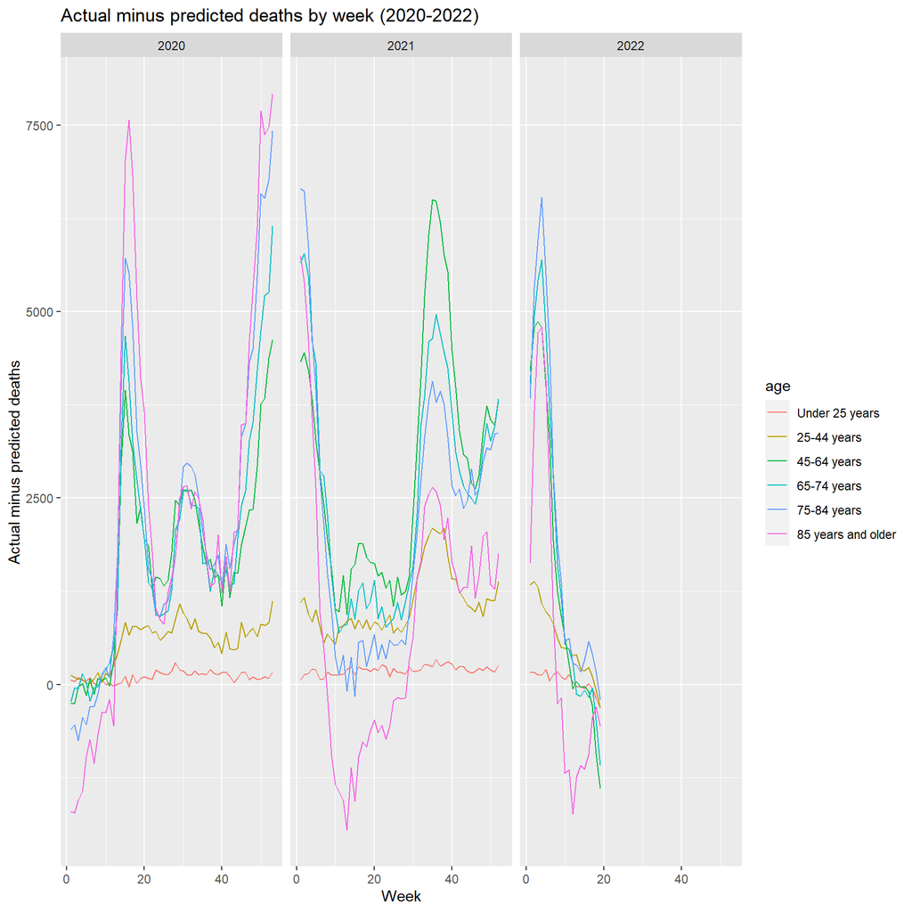

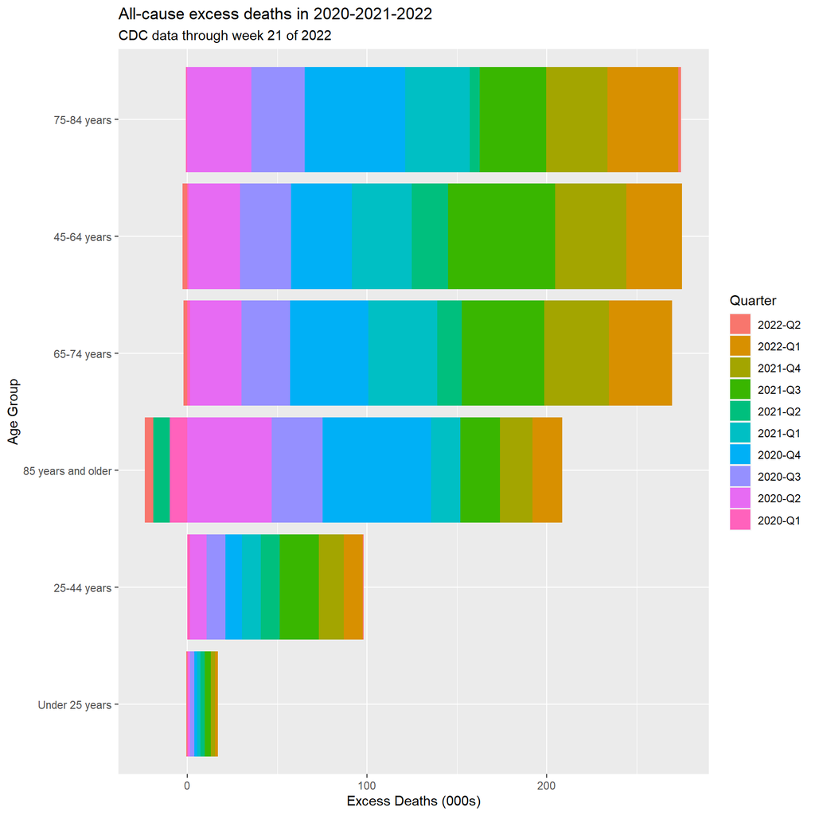

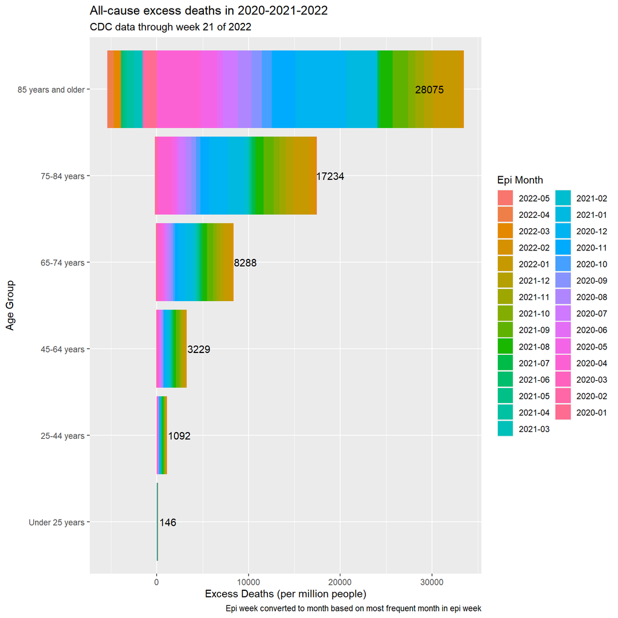

```r
saveToRDS(cdcList_20220623, ovrWriteError=FALSE)

# STEP 2: Latest death bu location-cause data
allCause_220623 <- analyzeAllCause(loc="COvID_deaths_age_place_20220623.csv",
                                   cdcDailyList=readFromRDS("cdc_daily_220602"),
                                   compareThruDate="2022-05-31"
                                   )
```

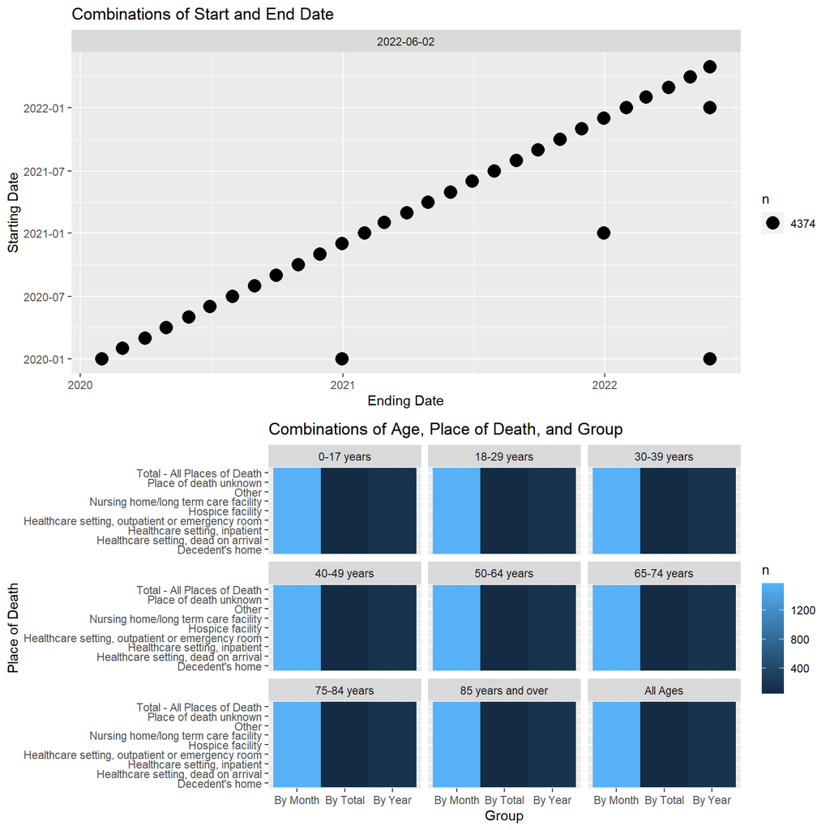

```
##
## States without abbreviations
## # A tibble: 2 x 10
## # Groups:   State [2]
##   State  abb    Year Month covidDeaths totalDeaths pneumoDeaths pneumoCovidDeat~
##   <chr>  <chr> <int> <int>       <dbl>       <dbl>        <dbl>            <dbl>
## 1 New Y~ <NA>      0     0       35136      170882        22567            13036
## 2 Puert~ <NA>      0     0        4311       78570        11023             3082
## # ... with 2 more variables: fluDeaths <dbl>, pnemoFluCovidDeaths <dbl>
```

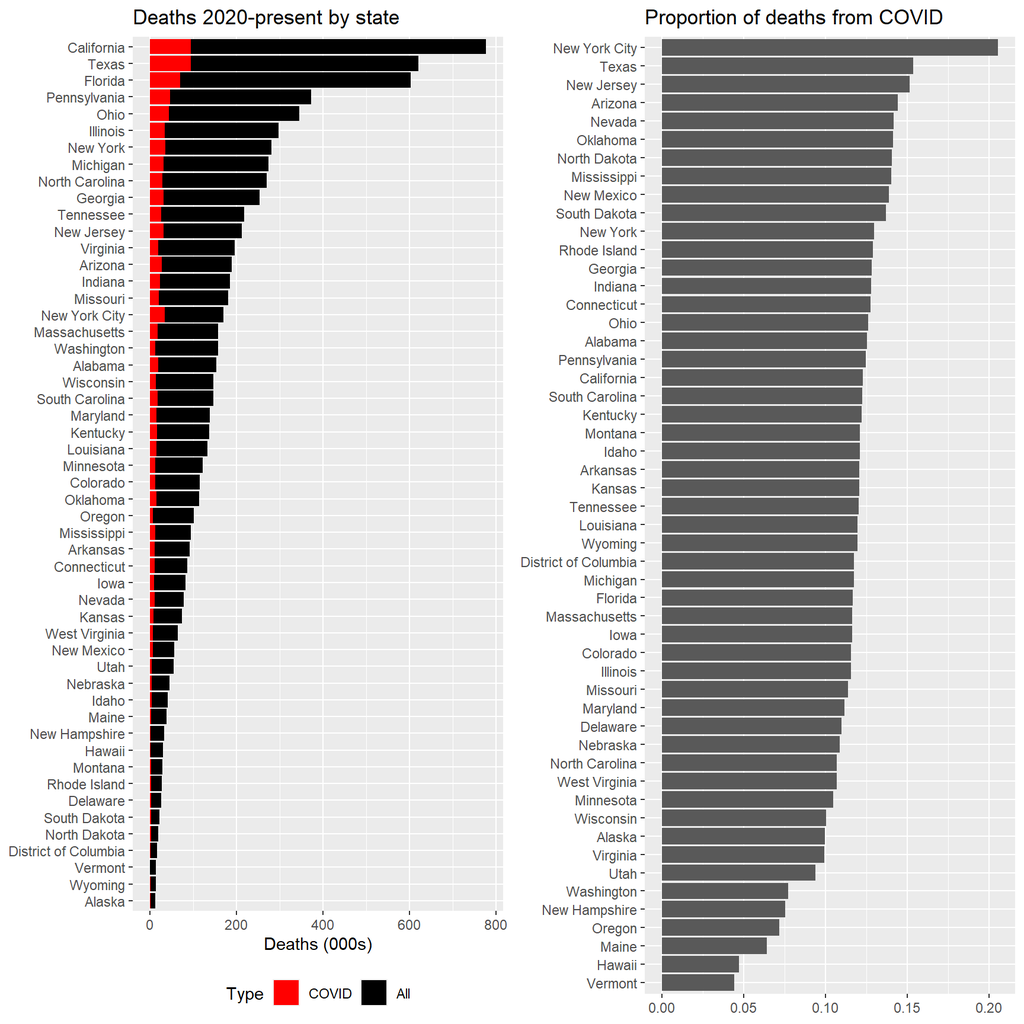

```
##
## Sub-lists are identical by: asofDate, startDate, endDate, Group, State, deathPlace, Age
```

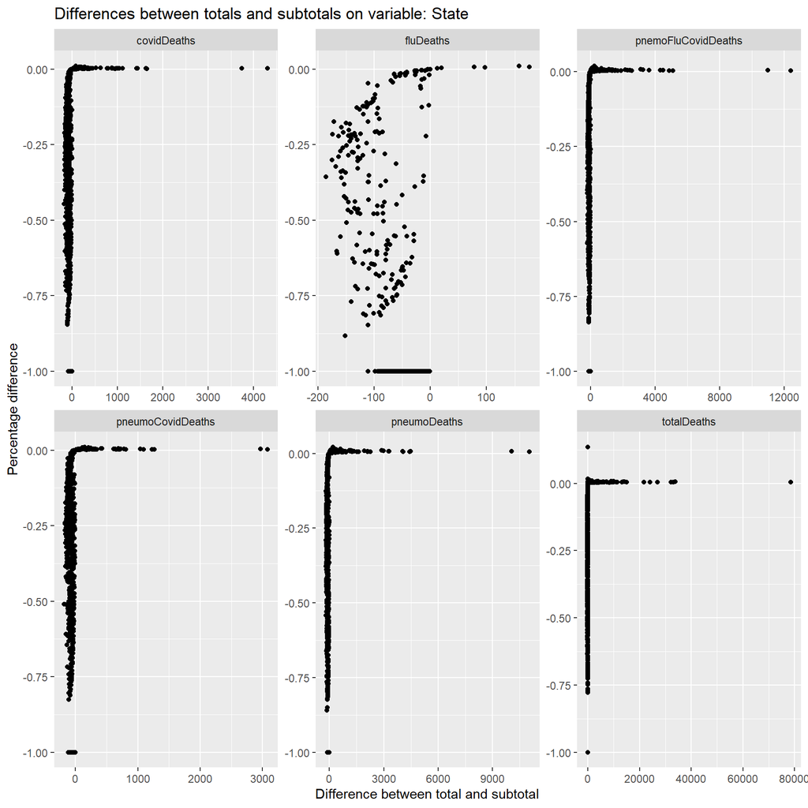

```
## # A tibble: 1,748 x 12
##    asofDate   startDate  endDate    Group  State  deathPlace   Age   name  dfSub
##    <date>     <date>     <date>     <chr>  <chr>  <chr>        <chr> <chr> <dbl>
##  1 2022-06-02 2020-10-01 2020-10-31 By Mo~ Unite~ Total - All~ 30-3~ pnem~   205
##  2 2022-06-02 2021-08-01 2021-08-31 By Mo~ Unite~ Other        All ~ pneu~   671
##  3 2022-06-02 2021-10-01 2021-10-31 By Mo~ Unite~ Decedent's ~ 40-4~ pnem~   149
##  4 2022-06-02 2020-02-01 2020-02-29 By Mo~ Unite~ Total - All~ 30-3~ pnem~    71
##  5 2022-06-02 2021-11-01 2021-11-30 By Mo~ Unite~ Healthcare ~ 75-8~ pnem~   139
##  6 2022-06-02 2020-11-01 2020-11-30 By Mo~ Unite~ Total - All~ 30-3~ pneu~   227
##  7 2022-06-02 2022-04-01 2022-04-30 By Mo~ Unite~ Total - All~ All ~ fluD~   168
##  8 2022-06-02 2020-08-01 2020-08-31 By Mo~ Unite~ Other        0-17~ tota~   116
##  9 2022-06-02 2020-09-01 2020-09-30 By Mo~ Unite~ Decedent's ~ 50-6~ pnem~   190
## 10 2022-06-02 2021-10-01 2021-10-31 By Mo~ Unite~ Decedent's ~ 65-7~ pneu~    86
## # ... with 1,738 more rows, and 3 more variables: dfTot <dbl>, delta <dbl>,
## #   pct <dbl>
##
## Sub-lists are identical by: asofDate, startDate, endDate, Group, State, deathPlace, Age
```

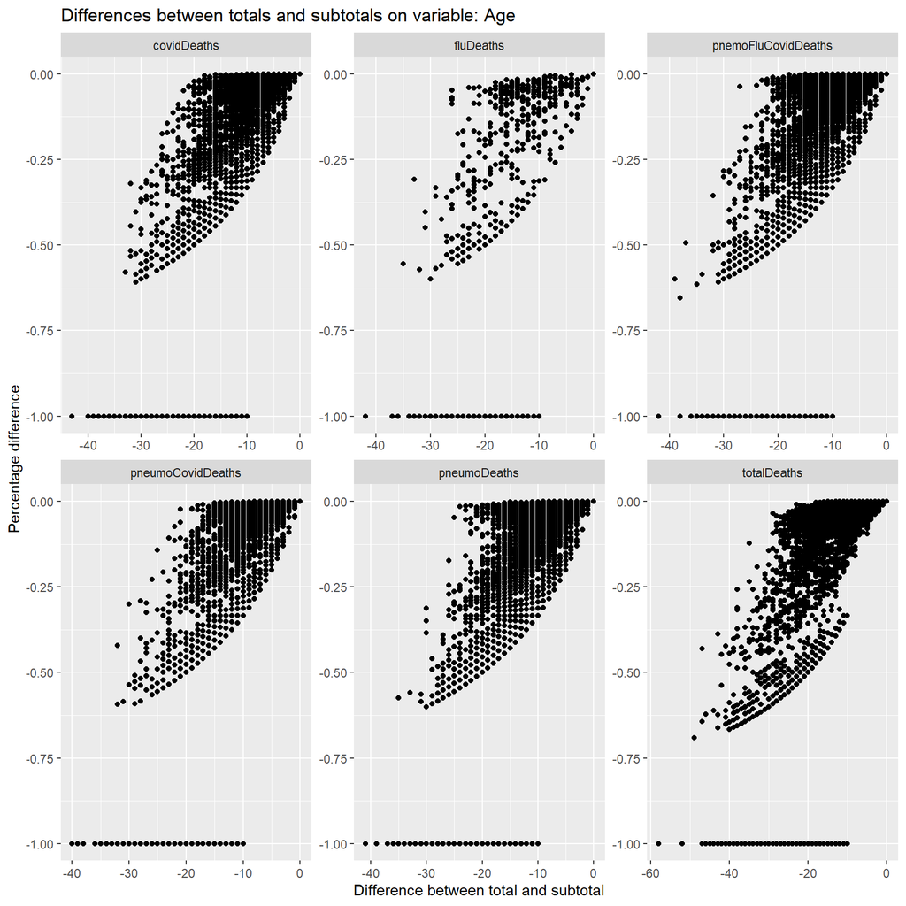

```
## # A tibble: 0 x 12
## # ... with 12 variables: asofDate <date>, startDate <date>, endDate <date>,
## #   Group <chr>, State <chr>, deathPlace <chr>, Age <chr>, name <chr>,
## #   dfSub <dbl>, dfTot <dbl>, delta <dbl>, pct <dbl>
##
## Sub-lists are identical by: asofDate, startDate, endDate, Group, State, deathPlace, Age
```

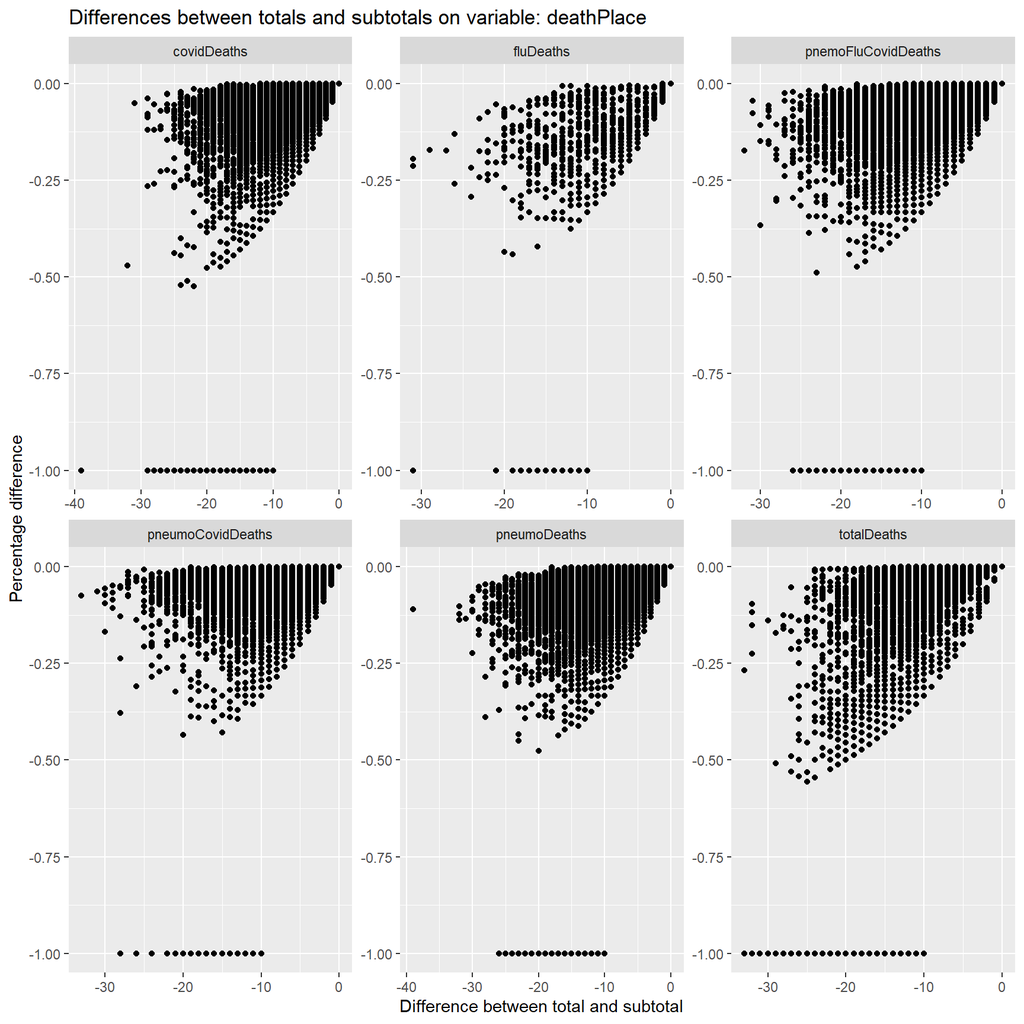

```
## # A tibble: 0 x 12
## # ... with 12 variables: asofDate <date>, startDate <date>, endDate <date>,
## #   Group <chr>, State <chr>, deathPlace <chr>, Age <chr>, name <chr>,
## #   dfSub <dbl>, dfTot <dbl>, delta <dbl>, pct <dbl>
```

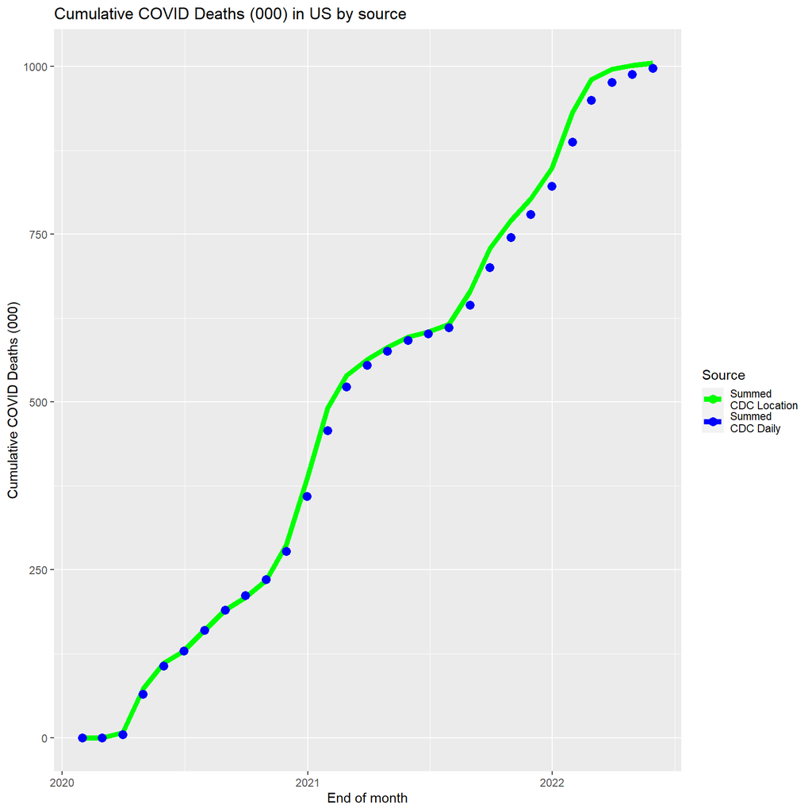

```
## # A tibble: 51 x 4
##    abb   cumValue tot_deaths pctdiff
##    <chr>    <dbl>      <dbl>   <dbl>
##  1 NY       36518      68346  0.304
##  2 DC        2010       1343  0.199
##  3 ND        2777       2283  0.0976
##  4 NC       28931      24660  0.0797
##  5 GA       32614      38198  0.0789
##  6 WY        1577       1820  0.0715
##  7 NE        4947       4290  0.0711
##  8 OH       43659      38628  0.0611
##  9 MI       32215      36357  0.0604
## 10 OK       16139      14420  0.0563
## # ... with 41 more rows
## # A tibble: 1 x 3
##   cumValue tot_deaths pctdiff
##      <dbl>      <dbl>   <dbl>
## 1   969868     997512    1.82
```

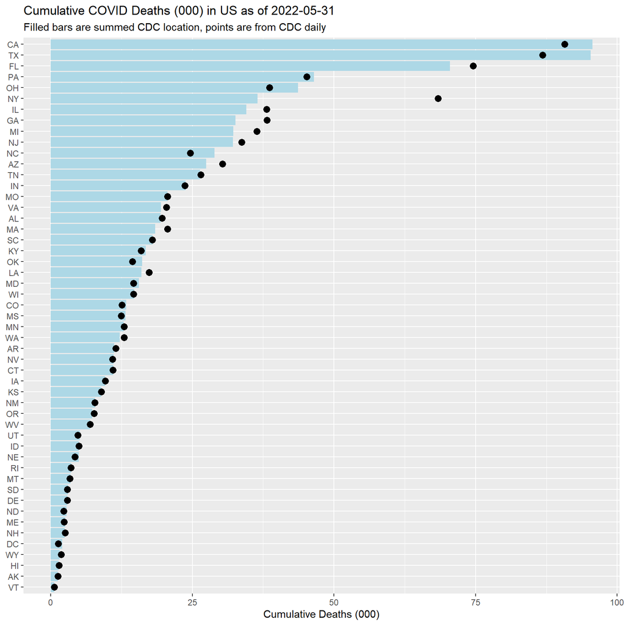

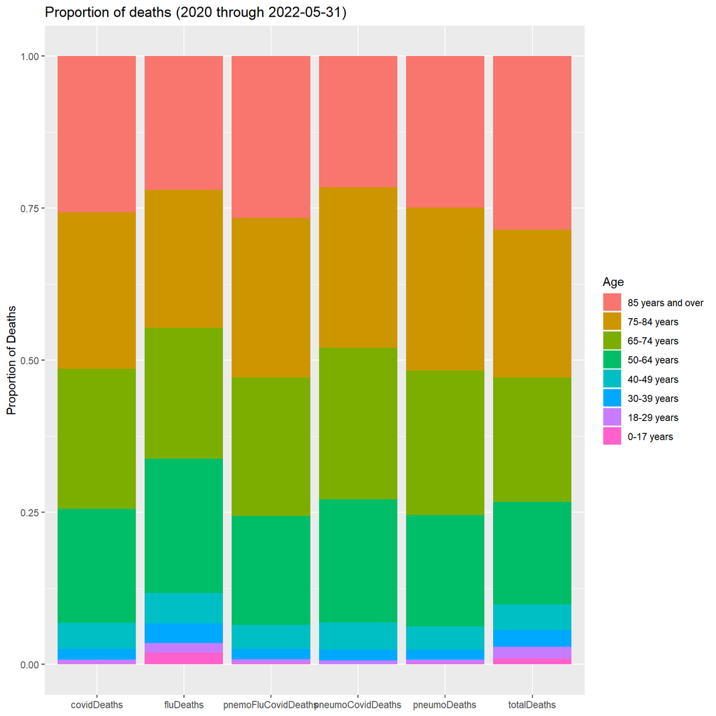

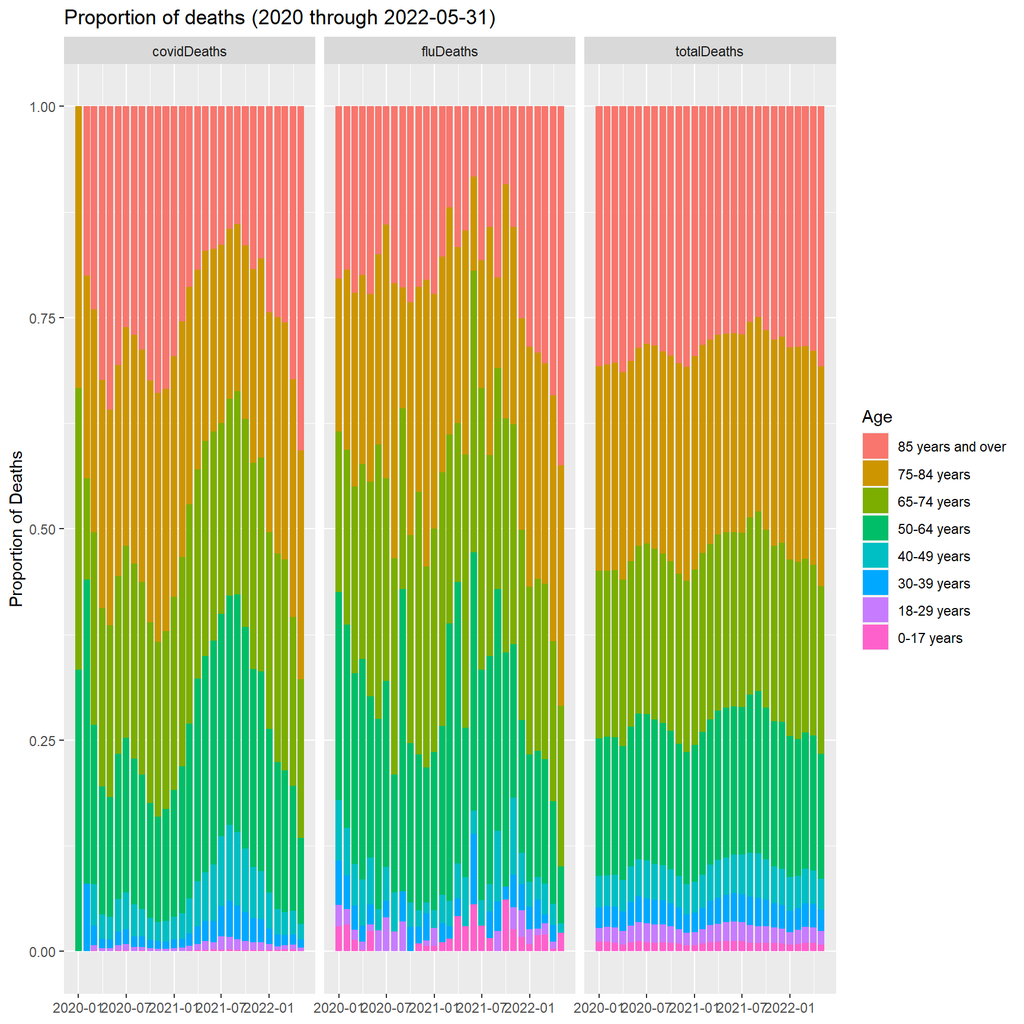

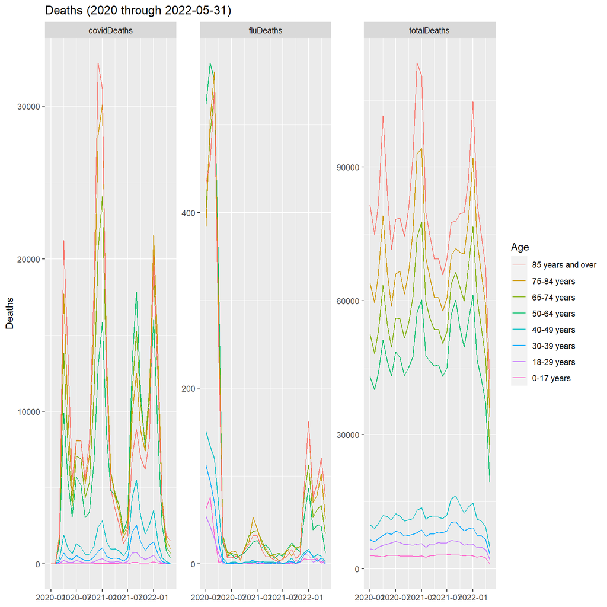

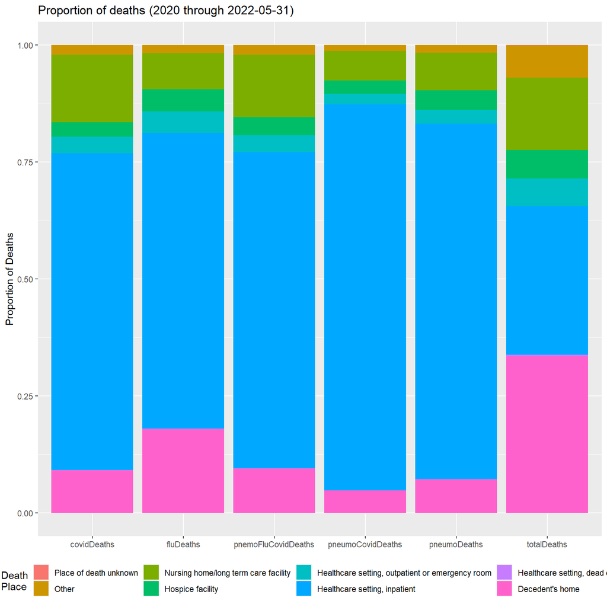

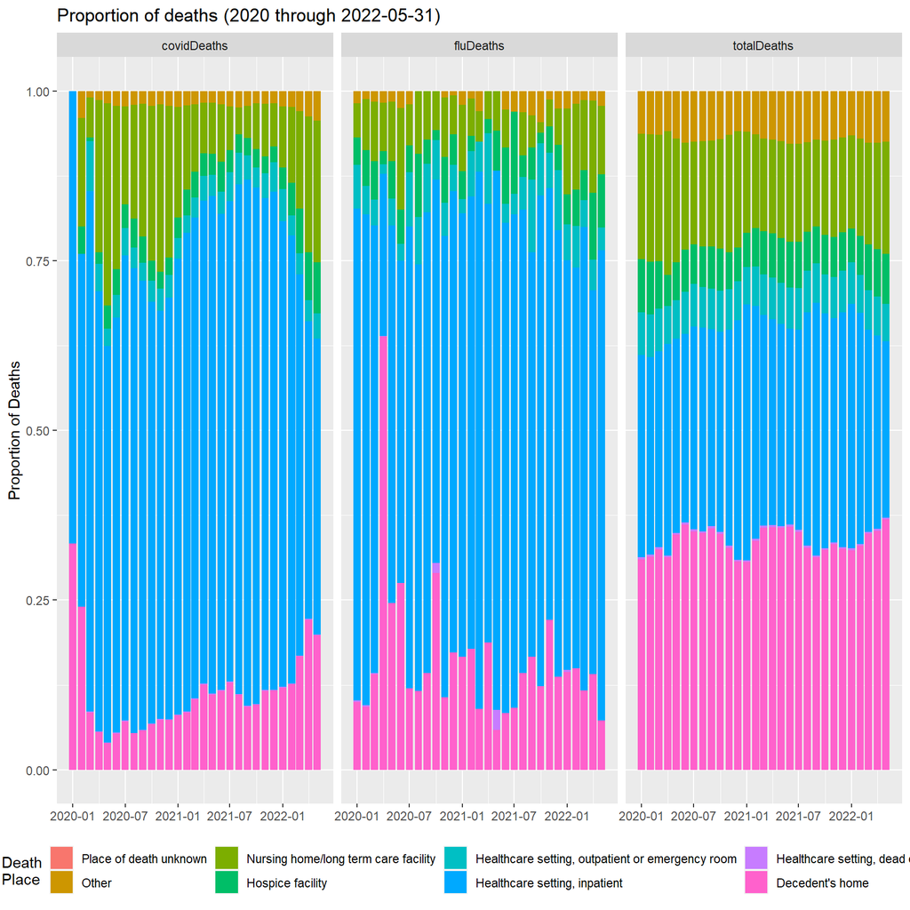